# TourismProject

## Context:

Tourism company named "Visit with us" wants to enable and establish a viable business model to expand the customer base. A viable business model will help them understand the existing ways of doing the business and how to change the ways for the benefit of the tourism sector. The company is offering 5 packages - Basic, Standard, Deluxe, Super Deluxe, King. Based on the data of last year, it was observed that 18% of the customers purchased the packages. From previous experience marketing cost was quite high because customers were contacted at random without looking at the data. Problem Statement: The company is now planning to launch a new product i.e. Wellness Tourism Package. Wellness Tourism is defined as Travel that allows the traveler to maintain, enhance or kick-start a healthy lifestyle, and support or increase one's sense of well-being. Company wants to harness the available data of existing and potential customers to make the marketing expenditure more efficient this time. As a Data Scientist at "Visit with us" travel company have to analyze the customers' data and information to provide recommendations to the Policy Maker and Marketing Team and also build a model to predict the potential customer who is going to purchase the newly introduced travel package.

## Objective:

• To predict which customer is more likely to purchase the newly introduced travel package.

## Data Description:

Customer details:

1. CustomerID: Unique customer ID
2. ProdTaken: Whether the customer has purchased a package or not (0: No, 1: Yes)
3. Age: Age of customer
4. TypeofContact: How customer was contacted (Company Invited or Self Inquiry)
5. CityTier: City tier depends on the development of a city, population, facilities, and living standards. The categories are ordered i.e. Tier 1 > Tier 2 > Tier 3
6. Occupation: Occupation of customer
7. Gender: Gender of customer
8. NumberOfPersonVisiting: Total number of persons planning to take the trip with the customer
9. PreferredPropertyStar: Preferred hotel property rating by customer
10. MaritalStatus: Marital status of customer
11. NumberOfTrips: Average number of trips in a year by customer
12. Passport: The customer has a passport or not (0: No, 1: Yes)
13. OwnCar: Whether the customers own a car or not (0: No, 1: Yes)
14. NumberOfChildrenVisiting: Total number of children with age less than 5 planning to take the trip with the customer
15. Designation: Designation of the customer in the current organization
16. MonthlyIncome: Gross monthly income of the customer Customer interaction data:
17. PitchSatisfactionScore: Sales pitch satisfaction score
18. ProductPitched: Product pitched by the salesperson
19. NumberOfFollowups: Total number of follow-ups has been done by the salesperson after the sales pitch
20. DurationOfPitch: Duration of the pitch by a salesperson to the customer

## Key Questions:

1. What are the key factors influencing the customers to take the travel package?
2. To what extent do each of the variables impact the decision to take the product?
3. What is the correlation between these attributes if any?
4. Is there a good predictive model for predicting customers who are likely to get the travel package? What does the performance assessment look like for such a model?

## Import Libraries

```python
import pandas as pd
import numpy as np
from sklearn import metrics
import matplotlib.pyplot as plt
%matplotlib inline
import warnings
warnings.filterwarnings('ignore')
import seaborn as sns
from sklearn.model_selection import train_test_split
from sklearn.model_selection import GridSearchCV
from sklearn import metrics
from sklearn.ensemble import BaggingClassifier, RandomForestClassifier, StackingClassifier
from sklearn.linear_model import LogisticRegression
# Libaries to help with data visualization
import matplotlib.pyplot as plt
import seaborn as sns
import math
import statistics
from sklearn.tree import DecisionTreeClassifier
from sklearn.ensemble import AdaBoostClassifier, GradientBoostingClassifier
#To install xgboost library use - !pip install xgboost
from xgboost import XGBClassifier
from sklearn.tree import DecisionTreeRegressor
from sklearn.ensemble import BaggingRegressor,RandomForestRegressor, GradientBoostingRegressor, AdaBoostRegressor, StackingRegressor
from xgboost import XGBRegressor
import warnings
warnings.filterwarnings("ignore")
```

```python
tourismdataDF = pd.read_csv("D:\\course\\TOURISM.CSV")
print(f'There are {tourismdataDF.shape[0]} rows and {tourismdataDF.shape[1]} columns.')  # f-string


np.random.seed(2) # setting the random seed via np.random.seed to get the same random result
tourismdataDF.sample(n=10) # 10 random rows
```

```
There are 4888 rows and 20 columns.
```

|  | CustomerID | ProdTaken | Age | TypeofContact | CityTier | DurationOfPitch | Occupation | Gender | NumberOfPersonVisiting | NumberOfFollowups | ProductPitched | PreferredPropertyStar | MaritalStatus | NumberOfTrips | Passport | PitchSatisfactionScore | OwnCar | NumberOfChildrenVisiting | Designation | MonthlyIncome |
| --- | --- | --- | --- | --- | --- | --- | --- | --- | --- | --- | --- | --- | --- | --- | --- | --- | --- | --- | --- | --- |
| 2055 | 202055 | 1 | 23.0 | Self Enquiry | 1 | 12.0 | Salaried | Male | 3 | 1.0 | Basic | 5.0 | Married | 2.0 | 1 | 3 | 0 | 0.0 | Executive | 16601.0 |
| 3626 | 203626 | 0 | 37.0 | Company Invited | 1 | 7.0 | Small Business | Female | 3 | 5.0 | Deluxe | 3.0 | Married | 2.0 | 0 | 5 | 1 | 2.0 | Manager | 23052.0 |
| 4812 | 204812 | 0 | 44.0 | Self Enquiry | 1 | 10.0 | Salaried | Male | 4 | 6.0 | King | NaN | Married | 5.0 | 0 | 5 | 1 | 1.0 | VP | 38418.0 |
| 3047 | 203047 | 0 | 46.0 | Self Enquiry | 1 | 9.0 | Salaried | Female | 4 | 5.0 | Basic | 3.0 | Single | 3.0 | 0 | 3 | 1 | 2.0 | Executive | 20952.0 |
| 121 | 200121 | 0 | 33.0 | Company Invited | 3 | 28.0 | Small Business | Male | 3 | 3.0 | Deluxe | 4.0 | Divorced | 1.0 | 0 | 2 | 0 | 1.0 | Manager | 21146.0 |
| 278 | 200278 | 0 | 26.0 | Company Invited | 1 | 6.0 | Salaried | Female | 2 | 3.0 | Deluxe | 4.0 | Married | 2.0 | 0 | 5 | 0 | 1.0 | Manager | 21397.0 |
| 3507 | 203507 | 0 | 30.0 | Self Enquiry | 3 | 26.0 | Salaried | Male | 4 | 5.0 | Deluxe | 3.0 | Married | 3.0 | 0 | 4 | 1 | 1.0 | Manager | 27298.0 |
| 3536 | 203536 | 0 | 46.0 | Self Enquiry | 1 | 35.0 | Large Business | Male | 4 | 4.0 | Basic | 3.0 | Married | 6.0 | 0 | 3 | 1 | 3.0 | Executive | 20810.0 |
| 1623 | 201623 | 0 | 45.0 | Self Enquiry | 1 | 15.0 | Salaried | Male | 2 | 3.0 | Deluxe | 4.0 | Married | 1.0 | 0 | 4 | 1 | 0.0 | Manager | 17348.0 |
| 1740 | 201740 | 0 | 55.0 | Self Enquiry | 1 | 6.0 | Small Business | Male | 2 | 3.0 | King | 5.0 | Single | 1.0 | 1 | 1 | 1 | 1.0 | VP | 34045.0 |

```python
tourismdataDF.shape
```

```
(4888, 20)
```

- The data contains 4888 rows and 20 columns

```python
tourismdataDF['ProdTaken'].value_counts()
```

```
0    3968
1     920
Name: ProdTaken, dtype: int64
```

**Check for duplicate values in the data.**

```python
tourismdataDF.duplicated().sum()
```

```
0
```

- There are no duplicate values in the dataset

**Summary of the dataset**

```python
tourismdataDF.describe(include="all").T
```

|  | count | unique | top | freq | mean | std | min | 25% | 50% | 75% | max |
| --- | --- | --- | --- | --- | --- | --- | --- | --- | --- | --- | --- |
| CustomerID | 4888 | NaN | NaN | NaN | 202444 | 1411.19 | 200000 | 201222 | 202444 | 203665 | 204887 |
| ProdTaken | 4888 | NaN | NaN | NaN | 0.188216 | 0.390925 | 0 | 0 | 0 | 0 | 1 |
| Age | 4662 | NaN | NaN | NaN | 37.6223 | 9.31639 | 18 | 31 | 36 | 44 | 61 |
| TypeofContact | 4863 | 2 | Self Enquiry | 3444 | NaN | NaN | NaN | NaN | NaN | NaN | NaN |
| CityTier | 4888 | NaN | NaN | NaN | 1.65426 | 0.916583 | 1 | 1 | 1 | 3 | 3 |
| DurationOfPitch | 4637 | NaN | NaN | NaN | 15.4908 | 8.51964 | 5 | 9 | 13 | 20 | 127 |
| Occupation | 4888 | 4 | Salaried | 2368 | NaN | NaN | NaN | NaN | NaN | NaN | NaN |
| Gender | 4888 | 3 | Male | 2916 | NaN | NaN | NaN | NaN | NaN | NaN | NaN |
| NumberOfPersonVisiting | 4888 | NaN | NaN | NaN | 2.90507 | 0.724891 | 1 | 2 | 3 | 3 | 5 |
| NumberOfFollowups | 4843 | NaN | NaN | NaN | 3.70845 | 1.00251 | 1 | 3 | 4 | 4 | 6 |
| ProductPitched | 4888 | 5 | Basic | 1842 | NaN | NaN | NaN | NaN | NaN | NaN | NaN |
| PreferredPropertyStar | 4862 | NaN | NaN | NaN | 3.58104 | 0.798009 | 3 | 3 | 3 | 4 | 5 |
| MaritalStatus | 4888 | 4 | Married | 2340 | NaN | NaN | NaN | NaN | NaN | NaN | NaN |
| NumberOfTrips | 4748 | NaN | NaN | NaN | 3.23652 | 1.84902 | 1 | 2 | 3 | 4 | 22 |
| Passport | 4888 | NaN | NaN | NaN | 0.290917 | 0.454232 | 0 | 0 | 0 | 1 | 1 |
| PitchSatisfactionScore | 4888 | NaN | NaN | NaN | 3.07815 | 1.36579 | 1 | 2 | 3 | 4 | 5 |
| OwnCar | 4888 | NaN | NaN | NaN | 0.620295 | 0.485363 | 0 | 0 | 1 | 1 | 1 |
| NumberOfChildrenVisiting | 4822 | NaN | NaN | NaN | 1.18727 | 0.857861 | 0 | 1 | 1 | 2 | 3 |
| Designation | 4888 | 5 | Executive | 1842 | NaN | NaN | NaN | NaN | NaN | NaN | NaN |
| MonthlyIncome | 4655 | NaN | NaN | NaN | 23619.9 | 5380.7 | 1000 | 20346 | 22347 | 25571 | 98678 |

```python
tourismdataDF.info()
```

```
<class 'pandas.core.frame.DataFrame'>
RangeIndex: 4888 entries, 0 to 4887
Data columns (total 20 columns):
 #   Column                    Non-Null Count  Dtype
---  ------                    --------------  -----
 0   CustomerID                4888 non-null   int64
 1   ProdTaken                 4888 non-null   int64
 2   Age                       4662 non-null   float64
 3   TypeofContact             4863 non-null   object
 4   CityTier                  4888 non-null   int64
 5   DurationOfPitch           4637 non-null   float64
 6   Occupation                4888 non-null   object
 7   Gender                    4888 non-null   object
 8   NumberOfPersonVisiting    4888 non-null   int64
 9   NumberOfFollowups         4843 non-null   float64
 10  ProductPitched            4888 non-null   object
 11  PreferredPropertyStar     4862 non-null   float64
 12  MaritalStatus             4888 non-null   object
 13  NumberOfTrips             4748 non-null   float64
 14  Passport                  4888 non-null   int64
 15  PitchSatisfactionScore    4888 non-null   int64
 16  OwnCar                    4888 non-null   int64
 17  NumberOfChildrenVisiting  4822 non-null   float64
 18  Designation               4888 non-null   object
 19  MonthlyIncome             4655 non-null   float64
dtypes: float64(7), int64(7), object(6)
memory usage: 763.9+ KB
```

```python
tourismdataDF.isnull().sum().sort_values(ascending=False)
```

```
DurationOfPitch             251
MonthlyIncome               233
Age                         226
NumberOfTrips               140
NumberOfChildrenVisiting     66
NumberOfFollowups            45
PreferredPropertyStar        26
TypeofContact                25
Passport                      0
MaritalStatus                 0
ProductPitched                0
Designation                   0
NumberOfPersonVisiting        0
Gender                        0
Occupation                    0
PitchSatisfactionScore        0
CityTier                      0
OwnCar                        0
ProdTaken                     0
CustomerID                    0
dtype: int64
```

- There are missing values mainly in Duration of Pitch, monthly income, Age, number of trips, number of children visiting , number of followups, Prefered Property star, Type of contact

**Number of unique values in each column**

```python
tourismdataDF.nunique()
```

```
CustomerID                  4888
ProdTaken                      2
Age                           44
TypeofContact                  2
CityTier                       3
DurationOfPitch               34
Occupation                     4
Gender                         3
NumberOfPersonVisiting         5
NumberOfFollowups              6
ProductPitched                 5
PreferredPropertyStar          3
MaritalStatus                  4
NumberOfTrips                 12
Passport                       2
PitchSatisfactionScore         5
OwnCar                         2
NumberOfChildrenVisiting       4
Designation                    5
MonthlyIncome               2475
dtype: int64
```

- We can drop 'CustomerID ' column as it is an ID variable and will not add value to the model.

```python
#Dropping two columns from the dataframe
tourismdataDF.drop(columns=['CustomerID'], inplace=True)
```

- Converting the columns with an 'object' datatype into categorical variables

```python
for feature in tourismdataDF.columns: # Loop through all columns in the dataframe
    if tourismdataDF[feature].dtype == 'object': # Only apply for columns with categorical strings
        tourismdataDF[feature] = pd.Categorical(tourismdataDF[feature])# Replace strings with an integer
tourismdataDF.head(10)
```

|  | ProdTaken | Age | TypeofContact | CityTier | DurationOfPitch | Occupation | Gender | NumberOfPersonVisiting | NumberOfFollowups | ProductPitched | PreferredPropertyStar | MaritalStatus | NumberOfTrips | Passport | PitchSatisfactionScore | OwnCar | NumberOfChildrenVisiting | Designation | MonthlyIncome |
| --- | --- | --- | --- | --- | --- | --- | --- | --- | --- | --- | --- | --- | --- | --- | --- | --- | --- | --- | --- |
| 0 | 1 | 41.0 | Self Enquiry | 3 | 6.0 | Salaried | Female | 3 | 3.0 | Deluxe | 3.0 | Single | 1.0 | 1 | 2 | 1 | 0.0 | Manager | 20993.0 |
| 1 | 0 | 49.0 | Company Invited | 1 | 14.0 | Salaried | Male | 3 | 4.0 | Deluxe | 4.0 | Divorced | 2.0 | 0 | 3 | 1 | 2.0 | Manager | 20130.0 |
| 2 | 1 | 37.0 | Self Enquiry | 1 | 8.0 | Free Lancer | Male | 3 | 4.0 | Basic | 3.0 | Single | 7.0 | 1 | 3 | 0 | 0.0 | Executive | 17090.0 |
| 3 | 0 | 33.0 | Company Invited | 1 | 9.0 | Salaried | Female | 2 | 3.0 | Basic | 3.0 | Divorced | 2.0 | 1 | 5 | 1 | 1.0 | Executive | 17909.0 |
| 4 | 0 | NaN | Self Enquiry | 1 | 8.0 | Small Business | Male | 2 | 3.0 | Basic | 4.0 | Divorced | 1.0 | 0 | 5 | 1 | 0.0 | Executive | 18468.0 |
| 5 | 0 | 32.0 | Company Invited | 1 | 8.0 | Salaried | Male | 3 | 3.0 | Basic | 3.0 | Single | 1.0 | 0 | 5 | 1 | 1.0 | Executive | 18068.0 |
| 6 | 0 | 59.0 | Self Enquiry | 1 | 9.0 | Small Business | Female | 2 | 2.0 | Basic | 5.0 | Divorced | 5.0 | 1 | 2 | 1 | 1.0 | Executive | 17670.0 |
| 7 | 0 | 30.0 | Self Enquiry | 1 | 30.0 | Salaried | Male | 3 | 3.0 | Basic | 3.0 | Married | 2.0 | 0 | 2 | 0 | 1.0 | Executive | 17693.0 |
| 8 | 0 | 38.0 | Company Invited | 1 | 29.0 | Salaried | Male | 2 | 4.0 | Standard | 3.0 | Unmarried | 1.0 | 0 | 3 | 0 | 0.0 | Senior Manager | 24526.0 |
| 9 | 0 | 36.0 | Self Enquiry | 1 | 33.0 | Small Business | Male | 3 | 3.0 | Deluxe | 3.0 | Divorced | 7.0 | 0 | 3 | 1 | 0.0 | Manager | 20237.0 |

```python
print(tourismdataDF.ProdTaken.value_counts())
print(tourismdataDF.TypeofContact.value_counts())
print(tourismdataDF.CityTier.value_counts())
print(tourismdataDF.DurationOfPitch.value_counts())
print(tourismdataDF.Occupation.value_counts())
print(tourismdataDF.Gender.value_counts())
print(tourismdataDF.NumberOfPersonVisiting.value_counts())
print(tourismdataDF.NumberOfFollowups.value_counts())
print(tourismdataDF.ProductPitched.value_counts())
print(tourismdataDF.PreferredPropertyStar.value_counts())
print(tourismdataDF.MaritalStatus.value_counts())
print(tourismdataDF.NumberOfTrips.value_counts())
print(tourismdataDF.Passport.value_counts())
print(tourismdataDF.PitchSatisfactionScore.value_counts())
print(tourismdataDF.OwnCar.value_counts())
print(tourismdataDF.NumberOfChildrenVisiting.value_counts())
print(tourismdataDF.Designation.value_counts())
```

```
0    3968
1     920
Name: ProdTaken, dtype: int64
Self Enquiry       3444
Company Invited    1419
Name: TypeofContact, dtype: int64
1    3190
3    1500
2     198
Name: CityTier, dtype: int64
9.0      483
7.0      342
8.0      333
6.0      307
16.0     274
15.0     269
14.0     253
10.0     244
13.0     223
11.0     205
12.0     195
17.0     172
30.0      95
22.0      89
31.0      83
23.0      79
18.0      75
32.0      74
29.0      74
21.0      73
25.0      73
27.0      72
26.0      72
24.0      70
35.0      66
20.0      65
28.0      61
33.0      57
19.0      57
34.0      50
```

[output cut: 63 more lines]

```
Name: PitchSatisfactionScore, dtype: int64
1    3032
0    1856
Name: OwnCar, dtype: int64
1.0    2080
2.0    1335
0.0    1082
3.0     325
Name: NumberOfChildrenVisiting, dtype: int64
Executive         1842
Manager           1732
Senior Manager     742
AVP                342
VP                 230
Name: Designation, dtype: int64
```

- There is an additional category in gender because of type "Fe male". Including them under female.

```python
tourismdataDF['Gender'] = tourismdataDF['Gender'].replace(['Fe Male'],'Female')
```

```python
print(tourismdataDF.Gender.value_counts())
```

```
Male      2916
Female    1972
Name: Gender, dtype: int64
```

## Univariate Analysis

```python
# While doing uni-variate analysis of numerical variables we want to study their central tendency
# and dispersion.
# Let us write a function that will help us create boxplot and histogram for any input numerical
# variable.
# This function takes the numerical column as the input and returns the boxplots
# and histograms for the variable.
# Let us see if this help us write faster and cleaner code.
def histogram_boxplot(feature, figsize=(15,10), bins = None):
    """ Boxplot and histogram combined
    feature: 1-d feature array
    figsize: size of fig (default (9,8))
    bins: number of bins (default None / auto)
    """
    f2, (ax_box2, ax_hist2) = plt.subplots(nrows = 2, # Number of rows of the subplot grid= 2
                                           sharex = True, # x-axis will be shared among all subplots
                                           gridspec_kw = {"height_ratios": (.25, .75)},
                                           figsize = figsize
                                           ) # creating the 2 subplots
    sns.boxplot(feature, ax=ax_box2, showmeans=True, color='violet') # boxplot will be created and a star will indicate the mean value of the column
    sns.distplot(feature, kde=F, ax=ax_hist2, bins=bins,color = 'orange') if bins else sns.distplot(feature, kde=False, ax=ax_hist2,color='tab:cyan') # For histogram
    ax_hist2.axvline(np.mean(feature), color='purple', linestyle='--') # Add mean to the histogram
    ax_hist2.axvline(np.median(feature), color='black', linestyle='-') # Add median to the histogram
```

### Observations on Age

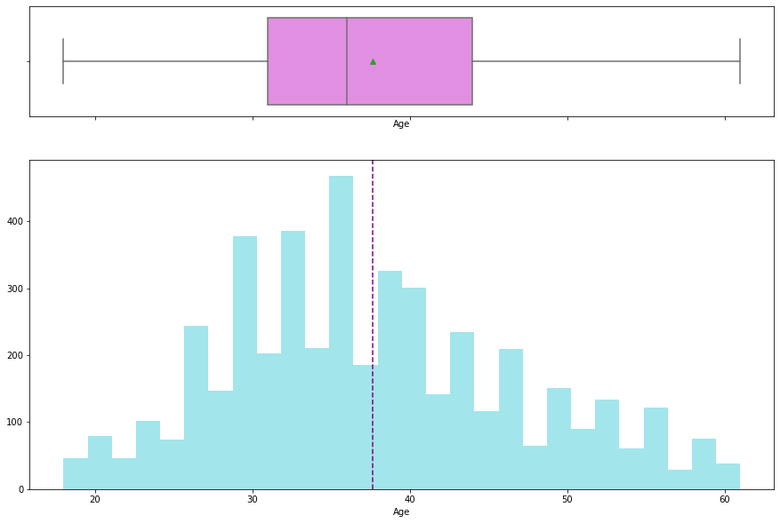

```python
histogram_boxplot(tourismdataDF.Age)
```

- Age has an approx symmetric distribution with mean around 38
- As evident from the boxplot, there are no outliers in the distribution for this variable

### Observations on DurationOfPitch

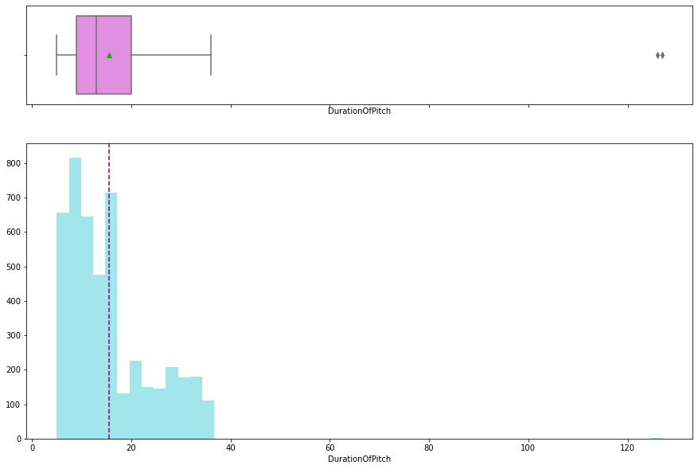

```python
histogram_boxplot(tourismdataDF.DurationOfPitch)
```

- Duration of Pitch is right skewed.
- As evident from the boxplot, there are a few outliers in this variable

### Observations on NumberOfPersonVisiting

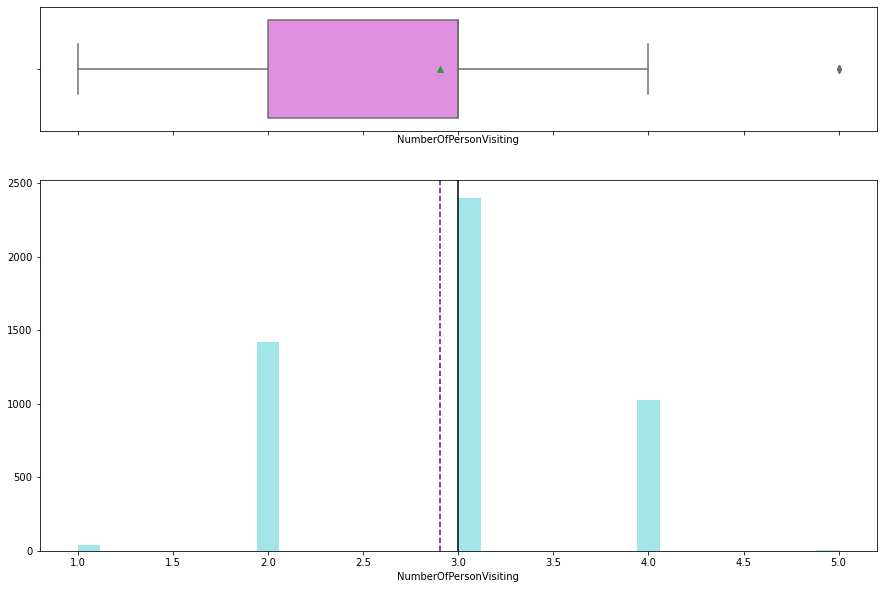

```python
histogram_boxplot(tourismdataDF.NumberOfPersonVisiting)
```

- Number of Persons visiting has an approx symmetric distribution with mean median close aroung 3

### Observations on NumberOfFollowups

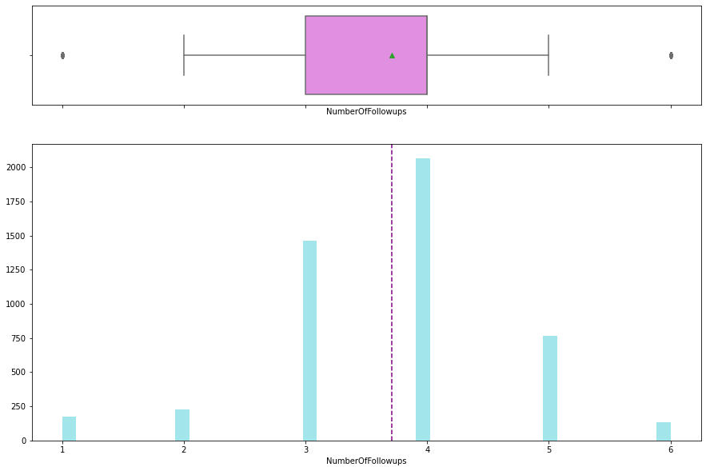

```python
histogram_boxplot(tourismdataDF.NumberOfFollowups)
```

### Observations on NumberOfTrips

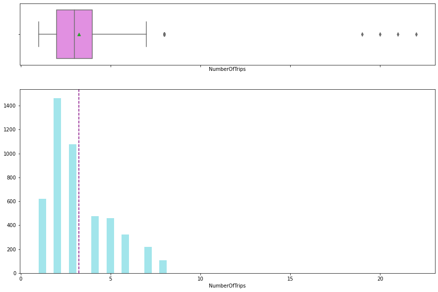

```python
histogram_boxplot(tourismdataDF.NumberOfTrips)
```

- Number of trips is right skewed.
- As evident from the boxplot, there are a outliers in this variable.

### Observations on NumberOfChildrenVisiting

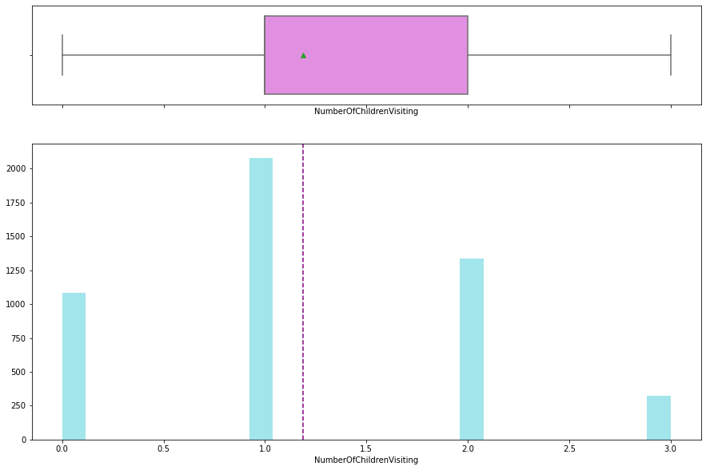

```python
histogram_boxplot(tourismdataDF.NumberOfChildrenVisiting)
```

### Observations on MonthlyIncome

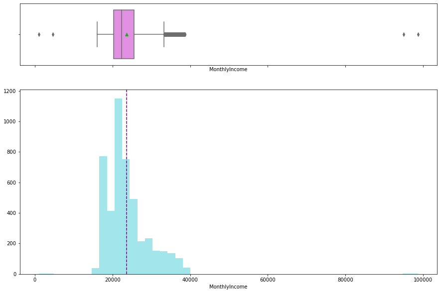

```python
histogram_boxplot(tourismdataDF.MonthlyIncome)
```

- Monthly income is a bit right skewed.
- As evident from the boxplot, there are outliers in this variable on either side.

```python
# Function to create barplots that indicate percentage for each category.

def perc_on_bar(z):
    '''
    plot
    feature: categorical feature
    the function won't work if a column is passed in hue parameter
    '''

    total = len(tourismdataDF[z]) # length of the column
    plt.figure(figsize=(15,5))
    #plt.xticks(rotation=45)
    ax = sns.countplot(tourismdataDF[z],palette='Paired')
    for p in ax.patches:
        percentage = '{:.1f}%'.format(100 * p.get_height()/total) # percentage of each class of the category
        x = p.get_x() + p.get_width() / 2 - 0.05 # width of the plot
        y = p.get_y() + p.get_height()           # hieght of the plot

        ax.annotate(percentage, (x, y), size = 12) # annotate the percantage
    plt.show() # show the plot
```

### Observations on ProdTaken

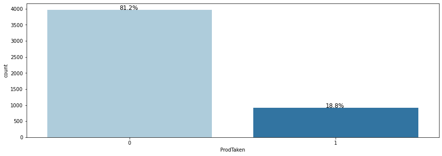

```python
perc_on_bar('ProdTaken')
```

- Only 19% of the customers have taken the product

### Observations on TypeofContact

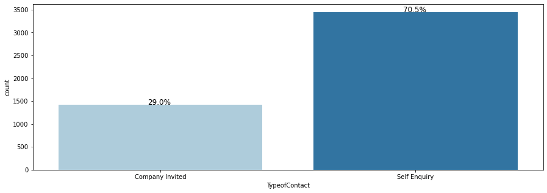

```python
perc_on_bar('TypeofContact')
```

- For 70% of the customers the contact was established using Self Inquiry

### Observations on CityTier

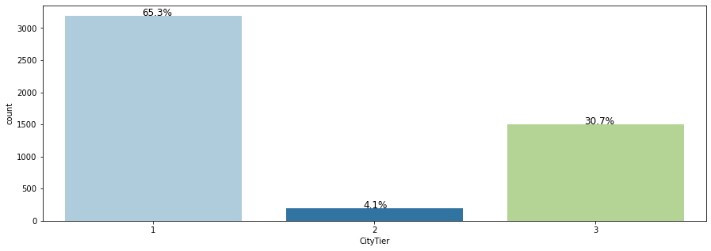

```python
perc_on_bar('CityTier')
```

- 65% of the customers come from tier1 city

### Observations on Occupation

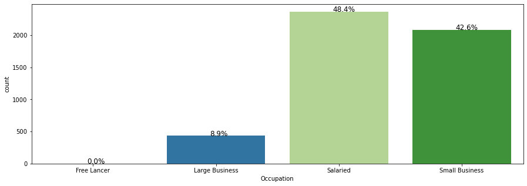

```python
perc_on_bar('Occupation')
```

- Mostly there are small business and salaried customers.

### Observations on Gender

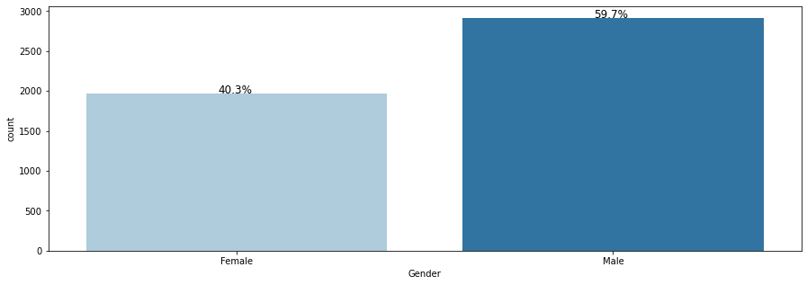

```python
perc_on_bar('Gender')
```

- 60% of customers are males.

### Observations on ProductPitched

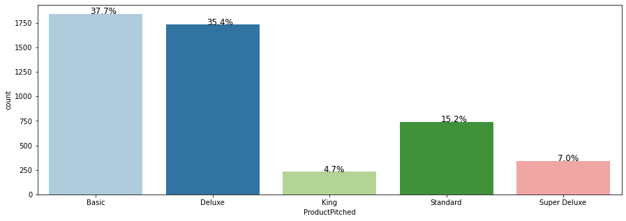

```python
perc_on_bar('ProductPitched')
```

- Basic and Deluxe products were pitched much more than the rest

### Observations on PreferredPropertyStar

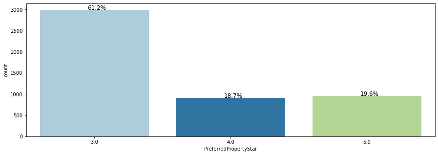

```python
perc_on_bar('PreferredPropertyStar')
```

- Prefered Hotel rating is 3 star

### Observations on MaritalStatus

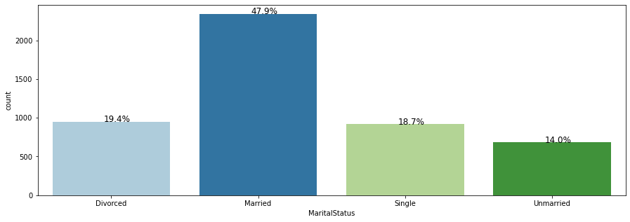

```python
perc_on_bar('MaritalStatus')
```

- Majority of customers are married.

### Observations on Passport

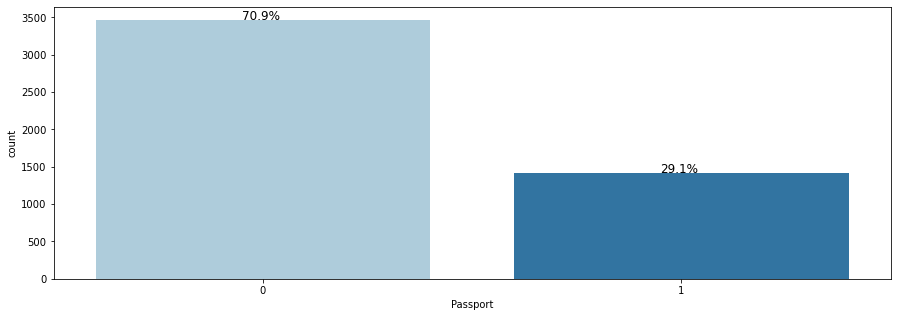

```python
perc_on_bar('Passport')
```

- Majority of customers do not have a passport so don't travel internationally

### Observations on OwnCar

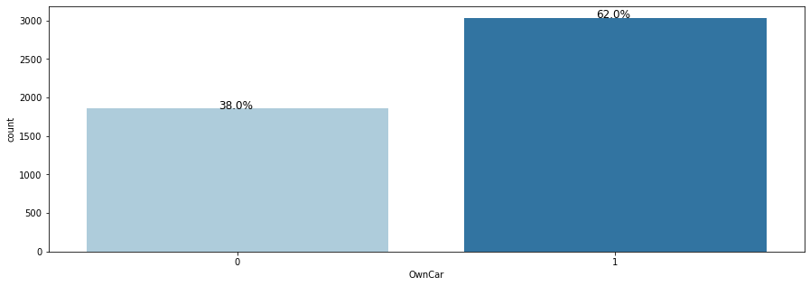

```python
perc_on_bar('OwnCar')
```

- Majoirty of customers have a car

### Observations on Designation

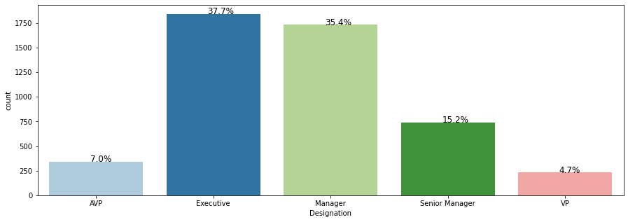

```python
perc_on_bar('Designation')
```

- Majority of customers have a executive or manager designation

## Bivariate analysis

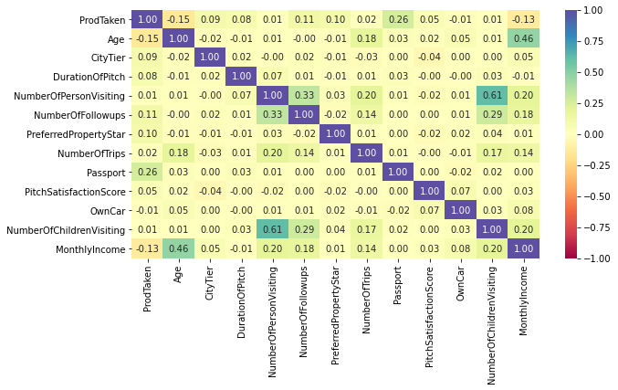

```python
plt.figure(figsize=(10,5))
sns.heatmap(tourismdataDF.corr(),annot=True,vmin=-1,vmax=1,fmt='.2f',cmap='Spectral')
plt.show()
```

- We can see that highest correlation exists with passport and product taken than any other variable with product taken
- There is a negative correlation between age and product taken. Older the customer less chance of taking the package.
- Age is positively correlated with Monthly income
- Expectedly there is a positive correlation between the number of persons visiting and number of children visiting.
- There is a slight correlation between monthly income and number of trips, number of persons visting and number of followups.

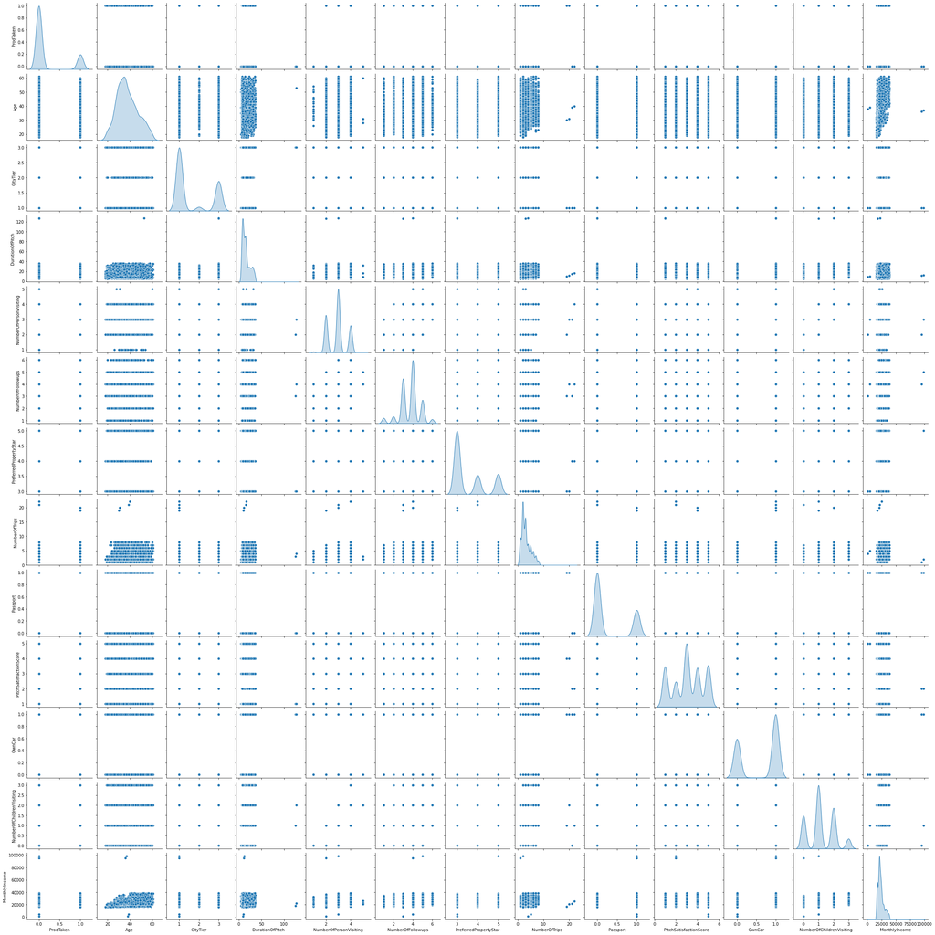

```python
sns.pairplot(tourismdataDF,diag_kind='kde')
```

```python
### Function to plot stacked bar charts for categorical columns
def stacked_plot(x):
    sns.set()
    ## crosstab
    tab1 = pd.crosstab(x,tourismdataDF['ProdTaken'],margins=True)
    print(tab1)
    print('-'*120)
    ## visualising the cross tab
    tab = pd.crosstab(x,tourismdataDF['ProdTaken'],normalize='index')
    tab.plot(kind='bar',stacked=True,figsize=(17,7))
    plt.legend(loc='lower left', frameon=False,)
    plt.legend(loc="upper left", bbox_to_anchor=(1,1))
    plt.show()
```

```
ProdTaken           0    1   All
TypeofContact
Company Invited  1109  310  1419
Self Enquiry     2837  607  3444
All              3946  917  4863
------------------------------------------------------------------------------------------------------------------------
```

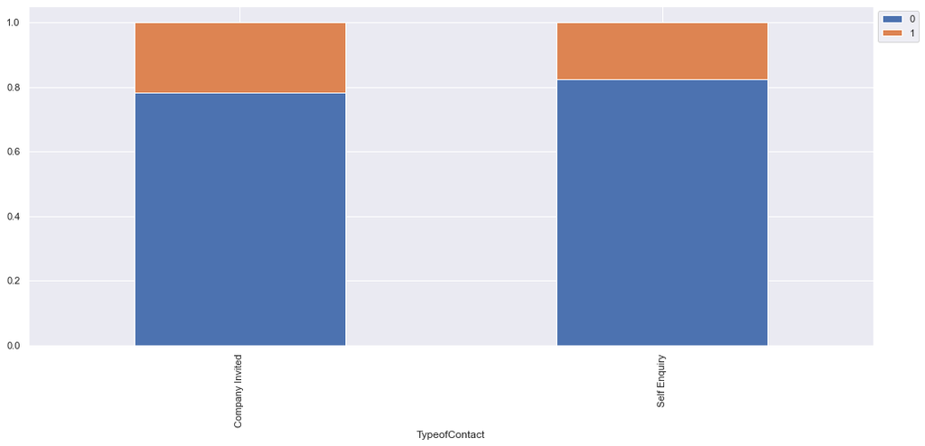

```python
stacked_plot(tourismdataDF['TypeofContact'])
```

- Product was taken slightly more with company invited customers as compared to the Self Inquiry

```
ProdTaken     0    1   All
CityTier
1          2670  520  3190
2           152   46   198
3          1146  354  1500
All        3968  920  4888
------------------------------------------------------------------------------------------------------------------------
```

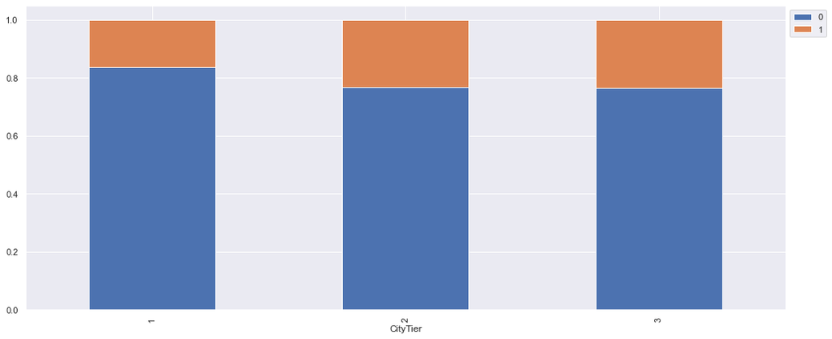

```python
stacked_plot(tourismdataDF['CityTier'])
```

- Product was taken more in Tier 2 and 3 cities.

```
ProdTaken          0    1   All
Occupation
Free Lancer        0    2     2
Large Business   314  120   434
Salaried        1954  414  2368
Small Business  1700  384  2084
All             3968  920  4888
------------------------------------------------------------------------------------------------------------------------
```

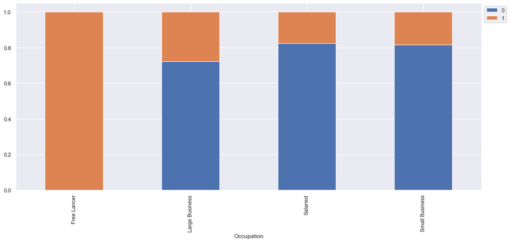

```python
stacked_plot(tourismdataDF['Occupation'])
```

- There are only 2 free lancers and both of them took the product
- Large business owners took the product more than salaried and small business owners

```
ProdTaken     0    1   All
Gender
Female     1630  342  1972
Male       2338  578  2916
All        3968  920  4888
------------------------------------------------------------------------------------------------------------------------
```

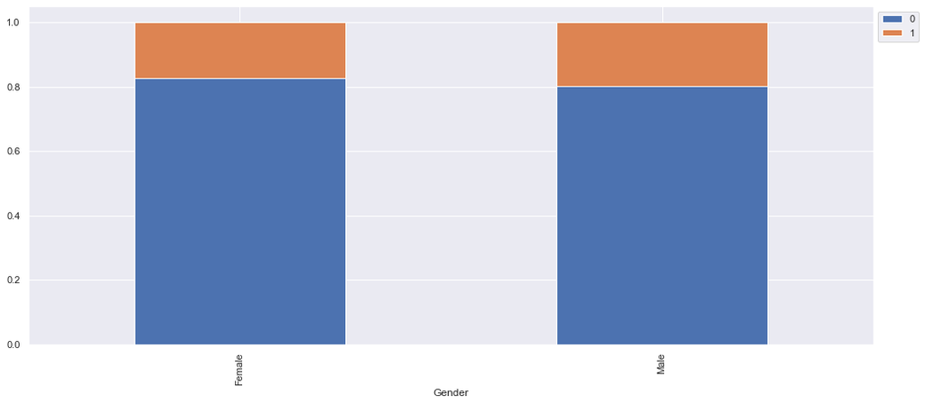

```python
stacked_plot(tourismdataDF['Gender'])
```

- The product is taken more by the males as compared to the females

```
ProdTaken          0    1   All
ProductPitched
Basic           1290  552  1842
Deluxe          1528  204  1732
King             210   20   230
Standard         618  124   742
Super Deluxe     322   20   342
All             3968  920  4888
------------------------------------------------------------------------------------------------------------------------
```

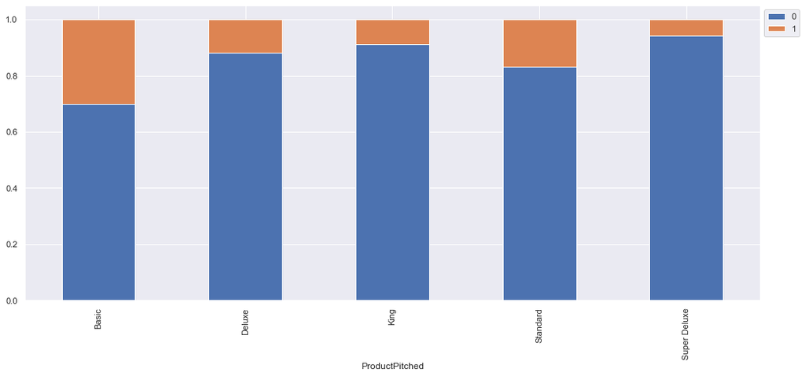

```python
stacked_plot(tourismdataDF['ProductPitched'])
```

- Out of the products pitched Basic was the most taken followed by standard.
- Super Deluxe was the least taken product

```
ProdTaken                 0    1   All
PreferredPropertyStar
3.0                    2511  482  2993
4.0                     731  182   913
5.0                     706  250   956
All                    3948  914  4862
------------------------------------------------------------------------------------------------------------------------
```

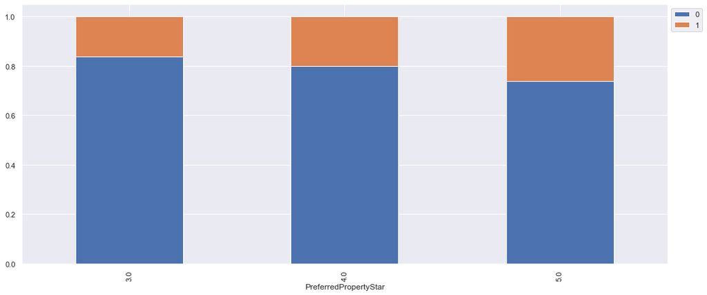

```python
stacked_plot(tourismdataDF['PreferredPropertyStar'])
```

- Product was taken with Prefered 5 star property

```
ProdTaken         0    1   All
MaritalStatus
Divorced        826  124   950
Married        2014  326  2340
Single          612  304   916
Unmarried       516  166   682
All            3968  920  4888
------------------------------------------------------------------------------------------------------------------------
```

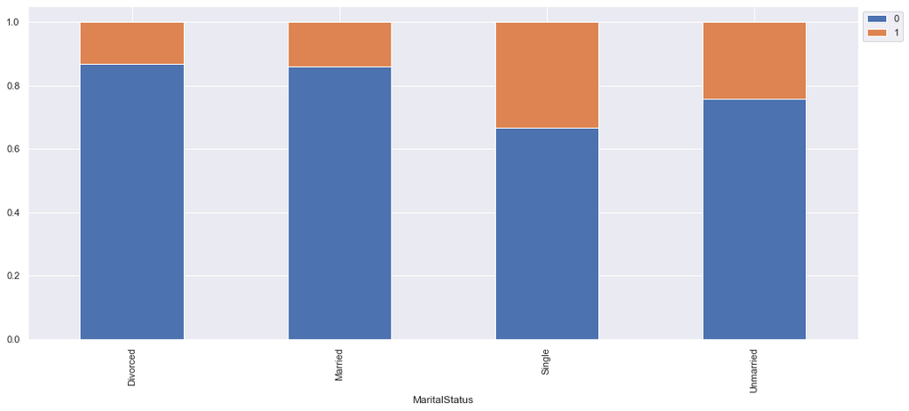

```python
stacked_plot(tourismdataDF['MaritalStatus'])
```

- Product was taken more by Unmarried and single people as compared to divourced and married.

```
ProdTaken     0    1   All
Passport
0          3040  426  3466
1           928  494  1422
All        3968  920  4888
------------------------------------------------------------------------------------------------------------------------
```

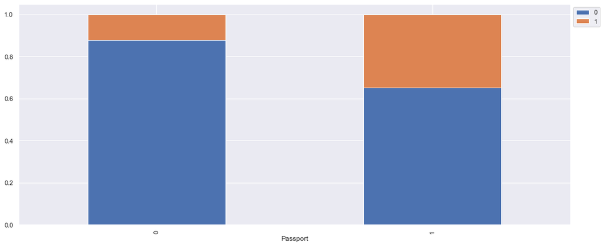

```python
stacked_plot(tourismdataDF['Passport'])
```

- Product was taken more by people with passports

```
ProdTaken          0    1   All
Designation
AVP              322   20   342
Executive       1290  552  1842
Manager         1528  204  1732
Senior Manager   618  124   742
VP               210   20   230
All             3968  920  4888
------------------------------------------------------------------------------------------------------------------------
```

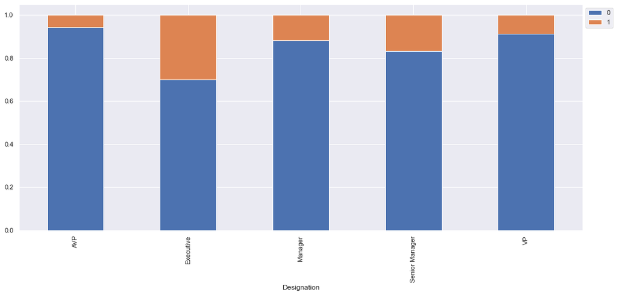

```python
stacked_plot(tourismdataDF['Designation'])
```

- Executives took the product more as compared to anyone else.

```
ProdTaken     0    1   All
OwnCar
0          1496  360  1856
1          2472  560  3032
All        3968  920  4888
------------------------------------------------------------------------------------------------------------------------
```

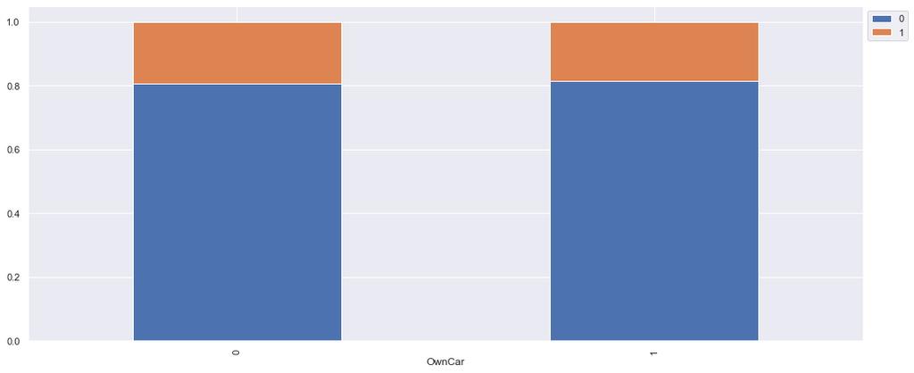

```python
stacked_plot(tourismdataDF['OwnCar'])
```

- Product was taken alsmot equally by people with car as compared to people without car

```
ProdTaken                  0    1   All
PitchSatisfactionScore
1                        798  144   942
2                        498   88   586
3                       1162  316  1478
4                        750  162   912
5                        760  210   970
All                     3968  920  4888
------------------------------------------------------------------------------------------------------------------------
```

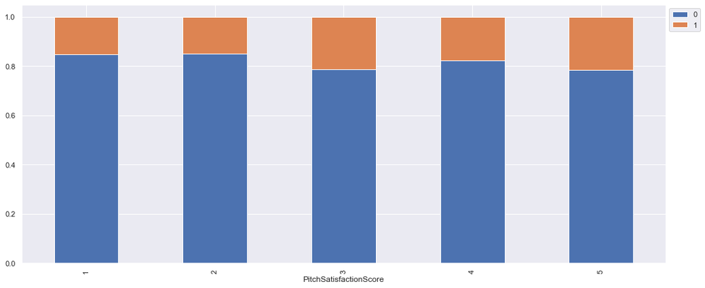

```python
stacked_plot(tourismdataDF['PitchSatisfactionScore'])
```

- Product was taken more by people who had sales pitch satisfaction score of 3 and 5

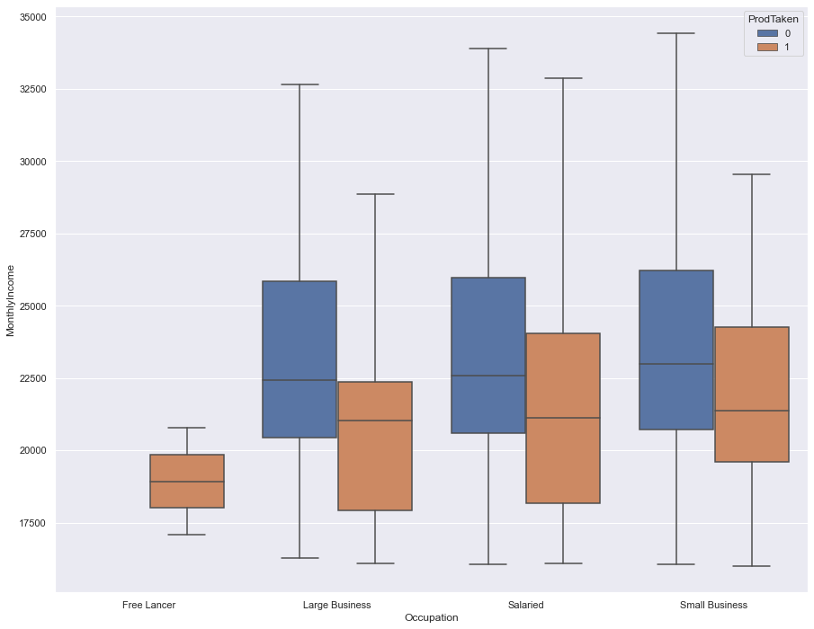

```python
# lets see how working hours per week vary across different occupation
plt.figure(figsize=(15,12))
sns.boxplot(y="MonthlyIncome", x="Occupation", data=tourismdataDF,hue='ProdTaken',showfliers=False);
```

- Relatively higher income customers for small business category took the product
- Range of salaried employees taking the product was more than any other category